# Notebook_05242017_Kim.Seungmo

```r
library(tidyverse)
```

#### 7.3.4 Exercises

1. Explore the distribution of each of the x, y, and z variables in diamonds. What do you learn? Think about a diamond and how you might decide which dimension is the length, width, and depth.

```r
head(diamonds)
```

```
## # A tibble: 6 × 10
##   carat       cut color clarity depth table price     x     y     z
##   <dbl>     <ord> <ord>   <ord> <dbl> <dbl> <int> <dbl> <dbl> <dbl>
## 1  0.23     Ideal     E     SI2  61.5    55   326  3.95  3.98  2.43
## 2  0.21   Premium     E     SI1  59.8    61   326  3.89  3.84  2.31
## 3  0.23      Good     E     VS1  56.9    65   327  4.05  4.07  2.31
## 4  0.29   Premium     I     VS2  62.4    58   334  4.20  4.23  2.63
## 5  0.31      Good     J     SI2  63.3    58   335  4.34  4.35  2.75
## 6  0.24 Very Good     J    VVS2  62.8    57   336  3.94  3.96  2.48
```

```r
summary(diamonds)
```

```
##      carat               cut        color        clarity
##  Min.   :0.2000   Fair     : 1610   D: 6775   SI1    :13065
##  1st Qu.:0.4000   Good     : 4906   E: 9797   VS2    :12258
##  Median :0.7000   Very Good:12082   F: 9542   SI2    : 9194
##  Mean   :0.7979   Premium  :13791   G:11292   VS1    : 8171
##  3rd Qu.:1.0400   Ideal    :21551   H: 8304   VVS2   : 5066
##  Max.   :5.0100                     I: 5422   VVS1   : 3655
##                                     J: 2808   (Other): 2531
##      depth           table           price             x
##  Min.   :43.00   Min.   :43.00   Min.   :  326   Min.   : 0.000
##  1st Qu.:61.00   1st Qu.:56.00   1st Qu.:  950   1st Qu.: 4.710
##  Median :61.80   Median :57.00   Median : 2401   Median : 5.700
##  Mean   :61.75   Mean   :57.46   Mean   : 3933   Mean   : 5.731
##  3rd Qu.:62.50   3rd Qu.:59.00   3rd Qu.: 5324   3rd Qu.: 6.540
##  Max.   :79.00   Max.   :95.00   Max.   :18823   Max.   :10.740
##
##        y                z
##  Min.   : 0.000   Min.   : 0.000
##  1st Qu.: 4.720   1st Qu.: 2.910
##  Median : 5.710   Median : 3.530
##  Mean   : 5.735   Mean   : 3.539
##  3rd Qu.: 6.540   3rd Qu.: 4.040
##  Max.   :58.900   Max.   :31.800
##
```

```r
## ???? Need help
```

2. Explore the distribution of price. Do you discover anything unusual or surprising? (Hint: Carefully think about the binwidth and make sure you try a wide range of values.)

```r
summary(diamonds$price)
```

```
##    Min. 1st Qu.  Median    Mean 3rd Qu.    Max.
##     326     950    2401    3933    5324   18823
```

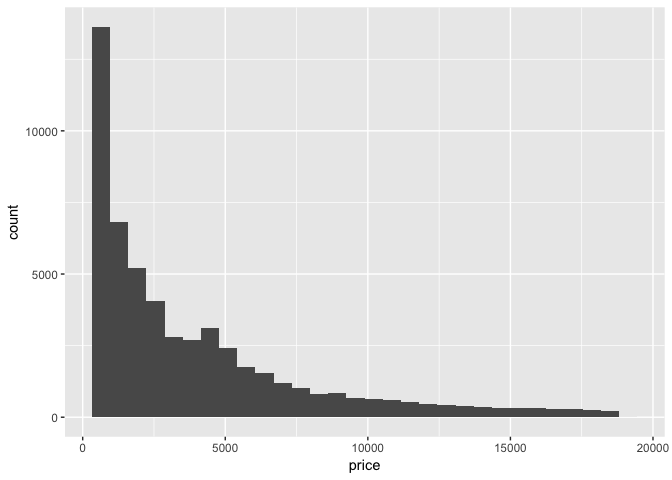

```r
p <- ggplot(diamonds, aes(x = price))
p + geom_histogram()
```

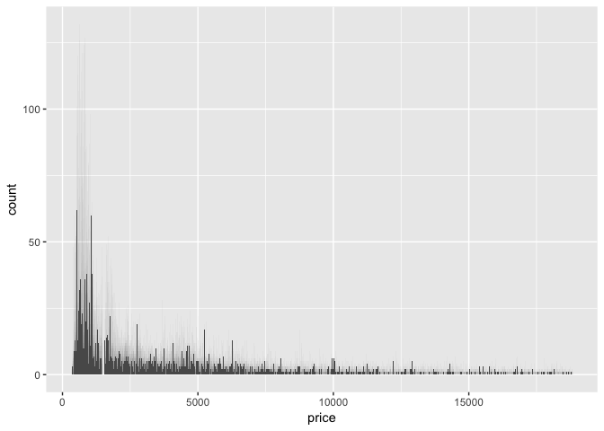

```r
p + geom_histogram(binwidth = 1)
```

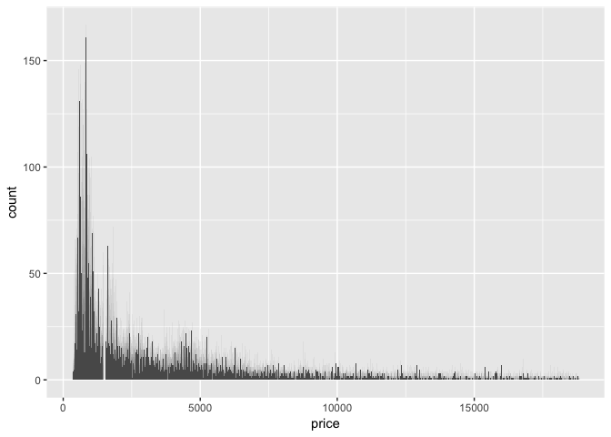

```r
p + geom_histogram(binwidth = 2)
```

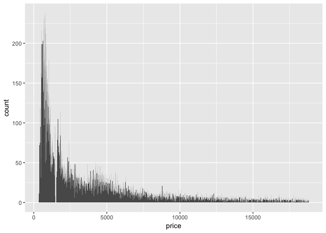

```r
p + geom_histogram(binwidth = 5)
```

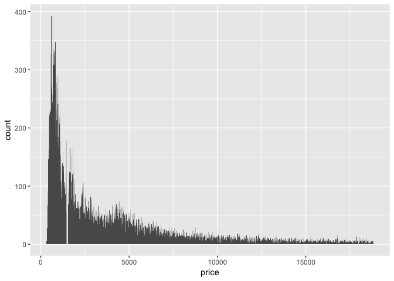

```r
p + geom_histogram(binwidth = 10)
```

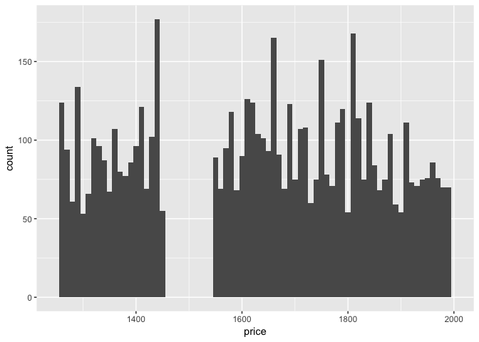

```r
p + geom_histogram(binwidth = 10) + xlim(1250, 2000)
```

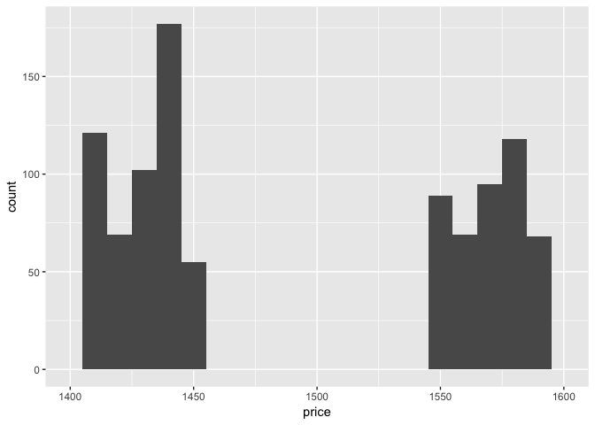

```r
p + geom_histogram(binwidth = 10) + xlim(1400, 1600)
```

No diamonds of $1450 to $1550.

3. How many diamonds are 0.99 carat? How many are 1 carat? What do you think is the cause of the difference?

```r
diamonds %>%
  filter(carat == 0.99 | carat == 1) %>%
  group_by(carat) %>%
  summarize(count= n())
```

```
## # A tibble: 2 × 2
##   carat count
##   <dbl> <int>
## 1  0.99    23
## 2  1.00  1558
```

People including me like at least ONE carat of diamonds, which means NOT SMALL. It is verified by my wife!

4. Compare and contrast coord_cartesian() vs xlim() or ylim() when zooming in on a histogram. What happens if you leave binwidth unset? What happens if you try and zoom so only half a bar shows?

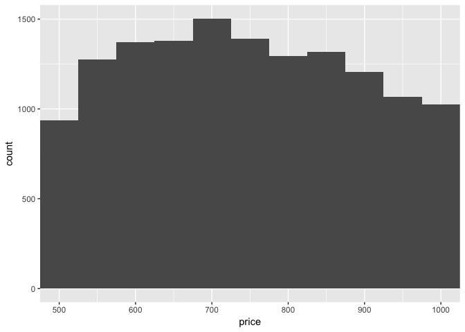

```r
p <- ggplot(diamonds, aes(x = price))

p + geom_histogram(binwidth = 50) + coord_cartesian(xlim=c(500, 1000))
```

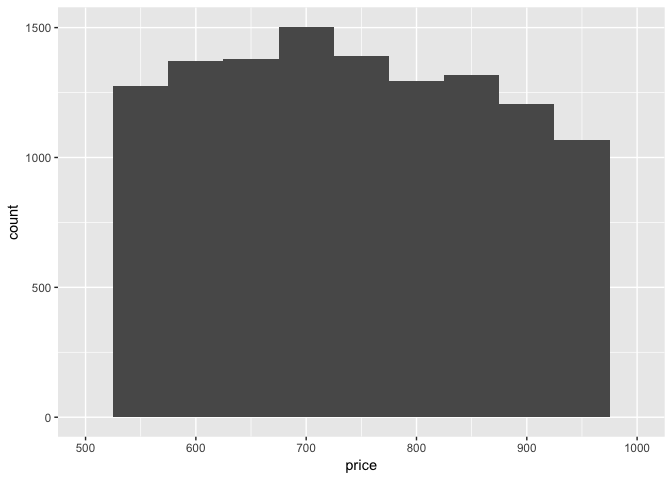

```r
p + geom_histogram(binwidth = 50) + xlim(500,1000)
```

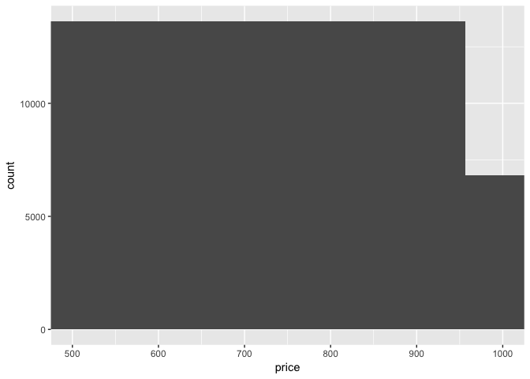

```r
# To show the designate range, xlim() or ylim() will remove but coord_cartesian() will not remove the outer range.

p + geom_histogram() + coord_cartesian(xlim=c(500, 1000))
```

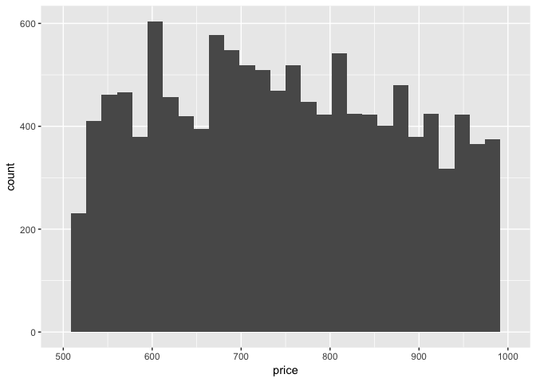

```r
p + geom_histogram() + xlim(500,1000)
```

```r
# coord_cartesian will not change and xlim() will change the binwidth to do each job.
```